# Enhancer Activity Umaps & Heatmap

In this .Rmd, we reproduce panel c and d from figure 2. In panel c, we plot the enhancer activity of two selected examples on the umap coordinates of the integrated Gene expression data from the Lib Alpha & Lib Beta screen. In panel d, we visualized scaled enhancer activity of the Lib Alpha screen using a heatmap.

# 1 Enhancer activity Umaps

```r
#reading in the integrated expression data
integrated <- readRDS(file = "~/cluster/project/SCG4SYN/Experiments/240524_scMPRA_LibBeta_HSC_iseq/screen_HSC/002_analysis/paper_figures/files_figshare/integrated_seurat.rds")

#read in enhancer count data from Lib Alpha screen
guides <- readRDS("~/cluster/project/SCG4SYN/Experiments/240524_scMPRA_LibBeta_HSC_iseq/screen_HSC/002_analysis/paper_figures/files_figshare/libAlpha_matched_gfp_guide_enhancer_counts.rds")
```

To plot enhancer activity on the umaps, we need to first extract the umap coordinates from the integrated seurat object per cell. Second, we will join this with the enhancer activity values per cell based on the cell labels and visualize the gfp UMI count.

```r
#get the umap coord & join it with enhancer count matrix
umapCoord <- as.data.frame(Embeddings(object = integrated[["umap"]])) %>% tibble(cell = colnames(integrated))

#fix cell annotations in umapCoord so that i can merge with guides table
umapCoord <- umapCoord |>
  filter(grepl("^Trp53\\.", cell)) |>
  mutate(cell = str_remove(cell, "^[^.]*\\."))

guides_umap <- left_join(guides, umapCoord)
```

Next, we are visualizing two enhancers of choice .

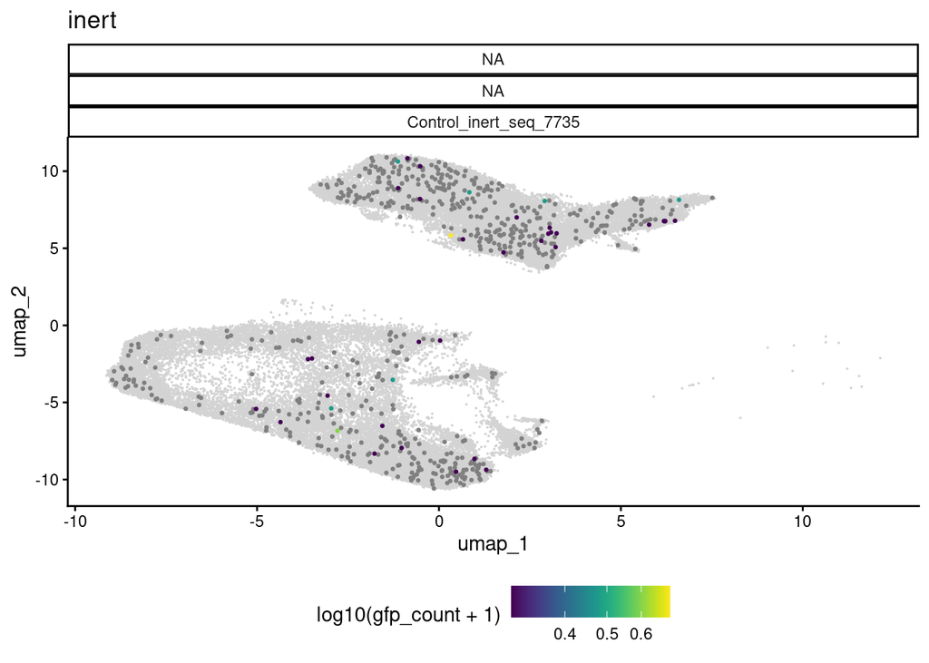

```r
#first im extracting the list of Sequence names for the different enhancers
seqs <- sort(unique(guides_umap$Seqname))

#this is the random DNA control i chose, because it has a nice coverage across the uamp
tf_subset <- guides_umap %>%
  filter(Seqname == "Control_inert_seq_7735") %>%
  arrange(gfp_count)

inert_single <- ggplot(tf_subset, aes(x = umap_1, y = umap_2)) +
  geom_point(data = umapCoord, aes(x= umap_1, y = umap_2), size = 0.01, color = "lightgrey") +
  geom_point(aes(x = umap_1, y = umap_2, color = log10(gfp_count+1)), size = 0.5) +
  theme_classic() +
  scale_color_viridis(option = "viridis", trans = "log10") +
  labs(title = "inert") +
  facet_wrap(nrepeats~TF1.affinity+Seqname) +
  theme(legend.position = "bottom")

inert_single
```

Now, I’m visualizing an enhancer that contains 3 Gata and 3 Cebpa motifs, that shows cell type-specific activity and iswell covered across diverse cell states/types.

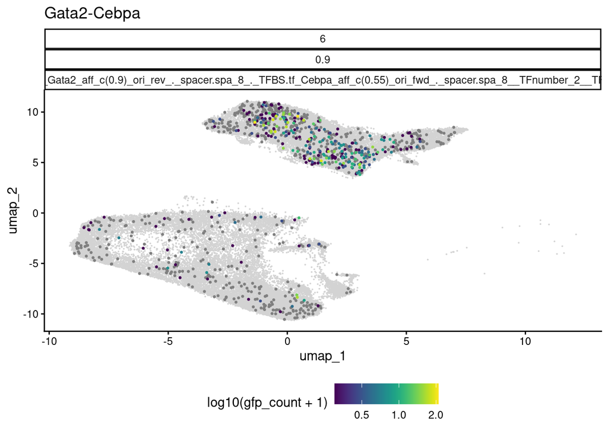

```r
tf_subset <- guides_umap %>%
  filter(Seqname == seqs[55] ) %>%
  arrange(gfp_count)

cebpa_single <- ggplot(tf_subset, aes(x = umap_1, y = umap_2)) +
  geom_point(data = umapCoord, aes(x= umap_1, y = umap_2), size = 0.01, color = "lightgrey") +
  geom_point(aes(x = umap_1, y = umap_2, color = log10(gfp_count+1)), size = 0.5) +
  theme_classic() +
  scale_color_viridis(option = "viridis", trans = "log10") +
  labs(title = "Gata2-Cebpa") +
  facet_wrap(nrepeats~TF1.affinity+Seqname) +
  theme(legend.position = "bottom")

both <- (cebpa_single + inert_single)
#ggsave("./011_example_umap_gata2_cebpa_inert.png", both, width=12, height=12, device = "png", units = "cm")

cebpa_single
```

# 2 Enhancer activity Heatmap

For Figure 2d, we visualized enhancer activity for all enhancer sequences, excluding the random DNA controls, in a clustered heatmap. Activity values were scaled per enhancer sequence across cell types, with enhancer sequences shown in columns and cluster or cell-type activities shown in rows. This representation highlights the relative activity pattern of each enhancer, making it easier to see in which cell type a given sequence is most active compared with the others.

First, we need to perform some data wrangling to get it into the right shape and get rid of unneeded cells.

```r
#subset seurat to Library Alpha screen
integrated_trp53 <- subset(integrated, experiment == "Trp53")
meta_cells <- integrated_trp53@meta.data %>% tibble(cell = colnames(integrated_trp53))


#Idents(integrated) <- integrated$final_annotation
# change cell annotation, so that i can merge with seurat meta data
guides <- guides |>
  dplyr::mutate(cell = paste0("Trp53.", cell))

#mergewith meta data to obtain cell type annotation
guides <- left_join(guides, meta_cells %>% select(final_annotation, cell))

guides <- guides |>
  mutate(#TF_combo = ifelse(TF_combo == "Gata1Cebpa", "Gata2Cebpa", TF_combo),
         cell = paste0("Trp53.", cell)) |>
  filter(TF.1 != "inert",
         !is.na(final_annotation) & !(final_annotation %in% c("EMPP", "HSC/MPP", "HSC/MPP cycling", "LMPP", "Unclear/Excluded"))) #because these are cell types present in the second Library Beta screen or excluded
```

```r
#aggregate counts at seqname, cluster level
crs.level.summary <- guides %>%
  dplyr::group_by(TF.1, TF.2, TF1.affinity, TF2.affinity, nrepeats, spacer, CRS, Seqname, ctrls, design_rep, Library, ControlFor, sequence,
                  TF1.orientation, TF2.orientation, TF_combo, final_annotation) %>%
  dplyr::summarise(
    mean_gfp = mean(ifelse(is.na(gfp_count), 0 , gfp_count)),
    n_guide = length(gfp_count)
  )

#prepare matrix for heatmap
gfp_wide <- crs.level.summary %>%
  dplyr::ungroup() %>%
  select(mean_gfp, final_annotation, Seqname) %>%
  pivot_wider(names_from = final_annotation, values_from = mean_gfp)
```

Here im defining all colors for the TF combinations and cell types.

```r
TF_colors <- c(
  "Cebpa"       = "#2E8B8B",
  "Fli1"        = "#C47AC0",
  "Gata1"       = "#88B04B",
  "Gata2"       = "#5CB8B2",
  "Gata2Cebpa"  = "#EE8468",
  "Gfi1b"       = "#EFC94C",
  "Gfi1bGata1"  = "#6CBF84",
  "Spi1"        = "#D46A6A",
  "Spi1Fli1"    = "#E88B3C",
  "Trp53"       = "#4477AA",
  "inert"       = "#C5C5C5"
)


another_pal<- c("Eo/Baso/Mast" = "#C43E2F",
                "Eo/Baso/Mast Progenitors" =  "#F26B55" ,
                "CD55+ immature" = "#E78C64",
                "Meg/Ery" = "#EDB93E",
                "Monocytes late" = "#6C9F8C",
                "Monocytes cycling" = "#217F5C",
                "Monocytes early" = "#33C38E",
                "Neutrophils" = "#25625E",
                "Early Myelocytes" = "#A0F2E8",
                "Monocyte precursor" = "#54BFB7",
                "Unclear/Excluded" = "grey",
                "Neutrophil precursor" = "#9ab1a9",
                "CD55- immature" = "#d2f9f4",
                "EMPP" = "#ff4dff",
                "LMPP" = "#9999ff",
                "HSC/MPP cycling" = "#7a0099",
                "HSC/MPP" = "#9900cc")
```

First, we build the heatmap matrix.

```r
## 0) Build the matrix first (rows = cell types, cols = Seqname)
mat <- scale(t(as.matrix(gfp_wide %>% select(-Seqname))))   # your scaled_columns_mat

#name them accordingly
colnames(mat) <- gfp_wide$Seqname
rownames(mat) <- colnames(gfp_wide)[-1]
```

Next we need to map the column and row annotations for the heatmap plotting.

```r
## 1) COLUMN annotation (TF per Seqname) — align by column names
tf_map <- crs.level.summary %>% distinct(Seqname, TF_combo)
tf_vec <- tf_map$TF_combo[match(colnames(mat), tf_map$Seqname)]
TF_colors_use <- TF_colors[intersect(names(TF_colors), unique(tf_vec))]

ha_col <- HeatmapAnnotation(
  TF = factor(tf_vec, levels = names(TF_colors_use)),
  col = list(TF = TF_colors_use),
  annotation_legend_param = list(title = "TF")
)


## 2) ROW annotation (cell type per row) — align by row names
row_celltypes <- rownames(mat)  # these are the cell types in row order
pal_use <- another_pal[intersect(names(another_pal), unique(row_celltypes))]

row_anno <- rowAnnotation(
  celltype = factor(row_celltypes, levels = names(pal_use)),
  col = list(celltype = pal_use)
)
```

Here, i perform a distance-based clustering for the heatmap.

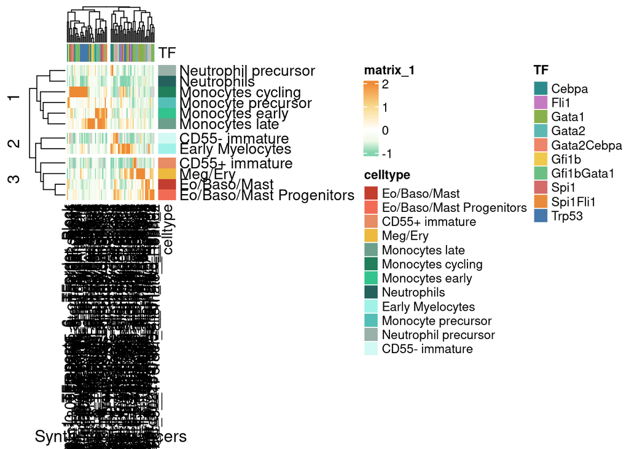

```r
scaled_columns_mat <- scale(t(as.matrix(gfp_wide %>% select(-Seqname))))
scaled_row_mat <- t(scale(as.matrix(gfp_wide %>% select(-Seqname))))

col_fun <- colorRamp2(c(-1, -0.5, 0, 1, 2), c("#84D4B0","#f0f9e8", "white","#F7DA8D", "#EF8A34")) # "#84D4B0"
dropout_gray <- "#D3D3D3"

# Draw heatmap
ht = Heatmap(
  mat,
  top_annotation = ha_col,
  right_annotation = row_anno,
  col = col_fun,
  na_col = dropout_gray,
  column_title = "Synthetic Enhancers",
  column_title_side = "bottom",
  clustering_distance_rows = "pearson",
  column_split = 2,
  row_split = 3
)

draw(ht)
```

This saves the plot.

```r
pdf("./012_heatmap_activity.pdf", width = 12, height = 8)

draw(ht)

dev.off()
```